# Regression Model for [Project Name] Using Python version 06

### 2.b) Data visualizations

##### 2.b.i) Univariate plots to better understand each attribute

```python
x_original = xy_original.drop(columns=['targetVar'])
```

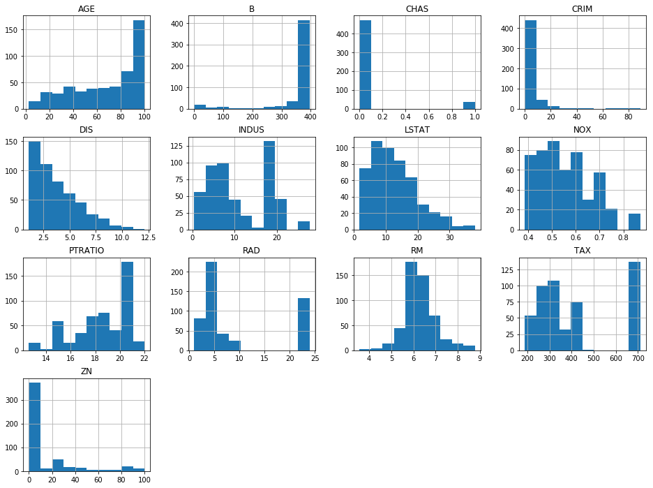

```python
# Histograms for each attribute
x_original.hist()
pyplot.show()
```

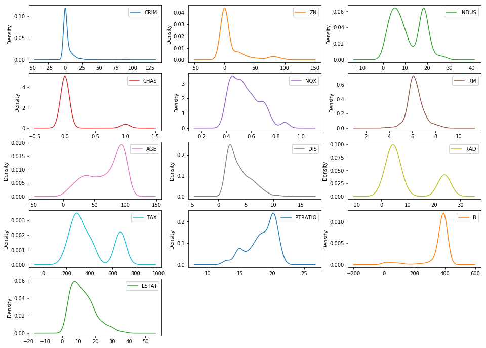

```python
# Density plot for each attribute
x_original.plot(kind='density', subplots=True, layout=(dispRow,dispCol), sharex=False, sharey=False)
pyplot.show()
```

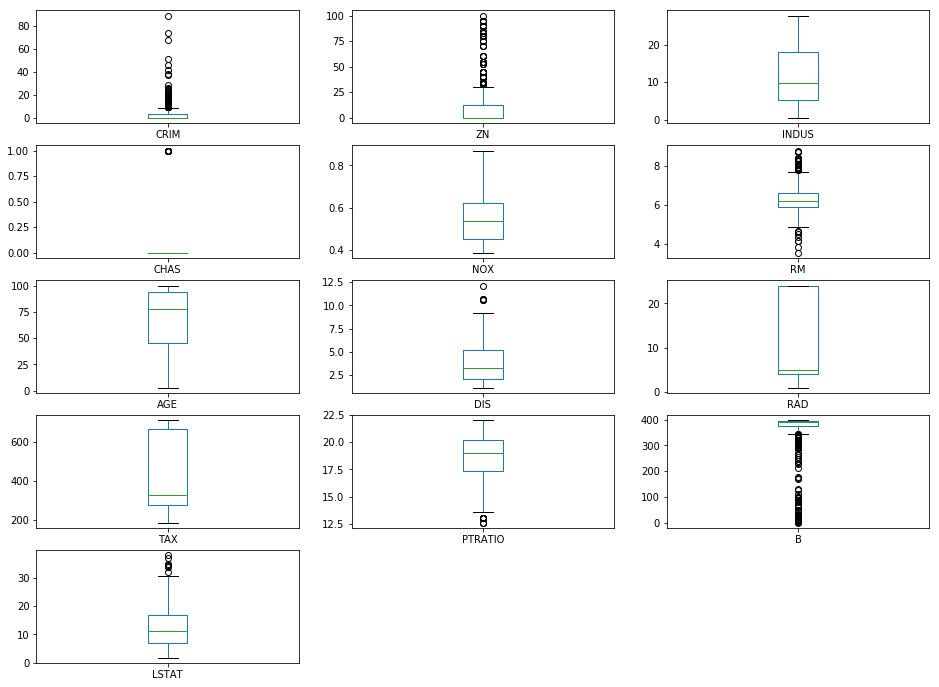

```python
# Box and Whisker plot for each attribute
x_original.plot(kind='box', subplots=True, layout=(dispRow,dispCol), sharex=False, sharey=False)
pyplot.show()
```

#### 2.b.ii) Multivariate plots to better understand the relationships between attributes

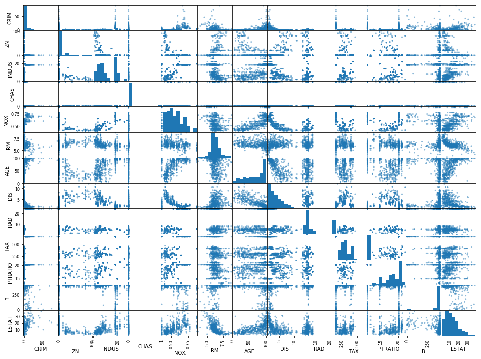

```python
# Scatterplot matrix
scatter_matrix(x_original)
pyplot.show()
```

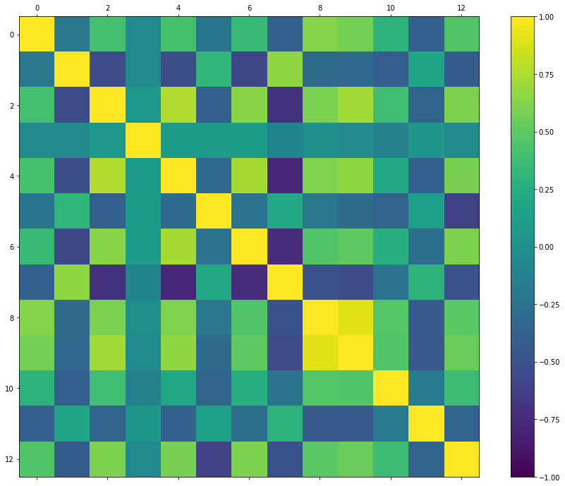

```python
# Correlation matrix
fig = pyplot.figure()
ax = fig.add_subplot(111)
cax = ax.matshow(x_original.corr(), vmin=-1, vmax=1)
fig.colorbar(cax)
pyplot.show()
```

```python
email_notify("Data Summarization and Visualization completed! "+datetime.now().strftime('%a %B %d, %Y %I:%M:%S %p'))
```

## Section 3 - Prepare Data

Some dataset may require additional preparation activities that will best exposes the structure of the problem and the relationships between the input attributes and the output variable. Some data-prep tasks might include:

- Cleaning data by removing duplicates, marking missing values and even imputing missing values.
- Feature selection where redundant features may be removed.
- Data transforms where attributes are scaled or redistributed in order to best expose the structure of the problem later to learning algorithms.

```python
email_notify("Data Cleaning and Transformation has begun! "+datetime.now().strftime('%a %B %d, %Y %I:%M:%S %p'))
```

### 3.a) Data Cleaning

```python
# Not applicable for this iteration of the project.
```

### 3.b) Feature Selection

```python
# Not applicable for this iteration of the project.
```

### 3.c) Data Transforms

```python
# Not applicable for this iteration of the project.
```

```python
email_notify("Data Cleaning and Transformation completed! "+datetime.now().strftime('%a %B %d, %Y %I:%M:%S %p'))
```

## 4. Model and Evaluate Algorithms

After the data-prep, we next work on finding a workable model by evaluating a subset of machine learning algorithms that are good at exploiting the structure of the training. The typical evaluation tasks include:

- Defining test options such as cross validation and the evaluation metric to use.
- Spot checking a suite of linear and nonlinear machine learning algorithms.
- Comparing the estimated accuracy of algorithms.

For this project, we will evaluate four linear, three non-linear, and three ensemble algorithms:

Linear Algorithms: Linear Regression, Ridge Regression, LASSO Regression, and Elastic Net Regression

Non-Linear Algorithms: Decision Trees (CART), k-Nearest Neighbors, and Support Vector Machine

Ensemble Algorithms: Random Forest, Extra Trees, and Stochastic Gradient Boosting

The random number seed is reset before each run to ensure that the evaluation of each algorithm is performed using the same data splits. It ensures the results are directly comparable.

### 4.a) Set test options and evaluation metric

```python
# Run algorithms using 10-fold cross validation
num_folds = 10
scoring = 'neg_mean_squared_error'
```

```python
# Set up Algorithms Spot-Checking Array
models = []
models.append(('LR', LinearRegression()))
models.append(('RR', Ridge()))
models.append(('LASSO', Lasso()))
models.append(('EN', ElasticNet()))
models.append(('CART', DecisionTreeRegressor(random_state=seedNum)))
models.append(('KNN', KNeighborsRegressor()))
models.append(('SVM', SVR()))
models.append(('RF', RandomForestRegressor(random_state=seedNum)))
models.append(('ET', ExtraTreesRegressor(random_state=seedNum)))
models.append(('GBM', GradientBoostingRegressor(random_state=seedNum)))
results = []
names = []
metrics = []
```

```python
# Generate model in turn
for name, model in models:
	email_notify("Algorithm "+name+" modeling has begun! "+datetime.now().strftime('%a %B %d, %Y %I:%M:%S %p'))
	startTimeModule = datetime.now()
	kfold = KFold(n_splits=num_folds, random_state=seedNum)
	cv_results = cross_val_score(model, x_train, y_train, cv=kfold, scoring=scoring)
	results.append(cv_results)
	names.append(name)
	metrics.append(cv_results.mean())
	msg = "%s: %f (%f)" % (name, cv_results.mean(), cv_results.std())
	print(msg)
	print ('Model training time:',(datetime.now() - startTimeModule))
	email_notify("Algorithm "+name+" modeling completed! "+datetime.now().strftime('%a %B %d, %Y %I:%M:%S %p'))
print ('Average metrics ('+scoring+') from all models:',np.mean(metrics))
```

```
LR: -25.612033 (13.351275)
Model training time: 0:00:00.011580
RR: -25.790544 (13.693551)
Model training time: 0:00:00.014714
LASSO: -29.758615 (14.872414)
Model training time: 0:00:00.012548
EN: -29.428369 (14.921289)
Model training time: 0:00:00.012194
CART: -22.339652 (15.928947)
Model training time: 0:00:00.027943
KNN: -50.328254 (29.718809)
Model training time: 0:00:00.012602
SVM: -88.911727 (29.338475)
Model training time: 0:00:00.061135
RF: -14.981121 (11.652530)
Model training time: 0:00:00.213698
ET: -15.083016 (9.266903)
Model training time: 0:00:00.155177
GBM: -13.145342 (10.777361)
Model training time: 0:00:00.401405
Average metrics (neg_mean_squared_error) from all models: -31.537867322967237
```

### 4.b) Spot-checking baseline algorithms

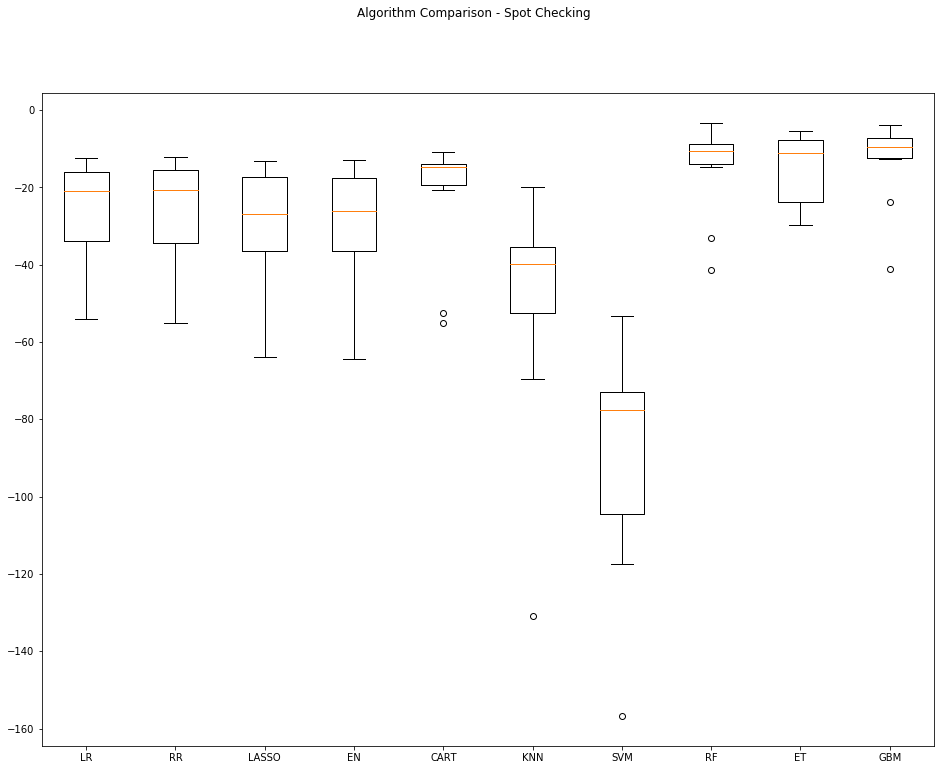

```python
fig = pyplot.figure()
fig.suptitle('Algorithm Comparison - Spot Checking')
ax = fig.add_subplot(111)
pyplot.boxplot(results)
ax.set_xticklabels(names)
pyplot.show()
```

## Section 5 - Improve Accuracy

After we achieve a short list of machine learning algorithms with good level of accuracy, we can leverage ways to improve the accuracy of the models.

### 5.a) Algorithm Tuning

```python
# Set up the comparison array
results = []
names = []
```

```python
# Tuning algorithm #1 - Random Forest
email_notify("Algorithm #1 tuning has begun! "+datetime.now().strftime('%a %B %d, %Y %I:%M:%S %p'))
startTimeModule = datetime.now()
paramGrid1 = dict(n_estimators=np.array([20,40,60,80,100]))
model1 = RandomForestRegressor(random_state=seedNum)
kfold = KFold(n_splits=num_folds, random_state=seedNum)
grid1 = GridSearchCV(estimator=model1, param_grid=paramGrid1, scoring=scoring, cv=kfold)
grid_result1 = grid1.fit(x_train, y_train)

print("Best: %f using %s" % (grid_result1.best_score_, grid_result1.best_params_))
results.append(grid_result1.cv_results_['mean_test_score'])
names.append('RF')
means = grid_result1.cv_results_['mean_test_score']
stds = grid_result1.cv_results_['std_test_score']
params = grid_result1.cv_results_['params']
for mean, stdev, param in zip(means, stds, params):
    print("%f (%f) with: %r" % (mean, stdev, param))
print ('Model training time:',(datetime.now() - startTimeModule))
email_notify("Algorithm #1 tuning completed! "+datetime.now().strftime('%a %B %d, %Y %I:%M:%S %p'))
```

```
Best: -13.550562 using {'n_estimators': 40}
-14.157638 (11.558897) with: {'n_estimators': 20}
-13.550562 (11.958646) with: {'n_estimators': 40}
-14.114891 (12.623699) with: {'n_estimators': 60}
-14.019512 (12.675438) with: {'n_estimators': 80}
-14.069409 (12.713605) with: {'n_estimators': 100}
Model training time: 0:00:06.460293
```

```python
# Tuning algorithm #2 - Stochastic Gradient Boosting
email_notify("Algorithm #2 tuning has begun! "+datetime.now().strftime('%a %B %d, %Y %I:%M:%S %p'))
startTimeModule = datetime.now()
paramGrid2 = dict(n_estimators=np.array([50,75,100,125,150]))
model2 = GradientBoostingRegressor(random_state=seedNum)
kfold = KFold(n_splits=num_folds, random_state=seedNum)
grid2 = GridSearchCV(estimator=model2, param_grid=paramGrid2, scoring=scoring, cv=kfold)
grid_result2 = grid2.fit(x_train, y_train)

print("Best: %f using %s" % (grid_result2.best_score_, grid_result2.best_params_))
results.append(grid_result2.cv_results_['mean_test_score'])
names.append('GBM')
means = grid_result2.cv_results_['mean_test_score']
stds = grid_result2.cv_results_['std_test_score']
params = grid_result2.cv_results_['params']
for mean, stdev, param in zip(means, stds, params):
    print("%f (%f) with: %r" % (mean, stdev, param))
print ('Model training time:',(datetime.now() - startTimeModule))
email_notify("Algorithm #2 tuning completed! "+datetime.now().strftime('%a %B %d, %Y %I:%M:%S %p'))
```

```
Best: -13.092781 using {'n_estimators': 100}
-13.819891 (11.346641) with: {'n_estimators': 50}
-13.147642 (10.944549) with: {'n_estimators': 75}
-13.092781 (10.732011) with: {'n_estimators': 100}
-13.179800 (10.883205) with: {'n_estimators': 125}
-13.232407 (10.999644) with: {'n_estimators': 150}
Model training time: 0:00:02.072829
```

### 5.b) Compare Algorithms After Tuning

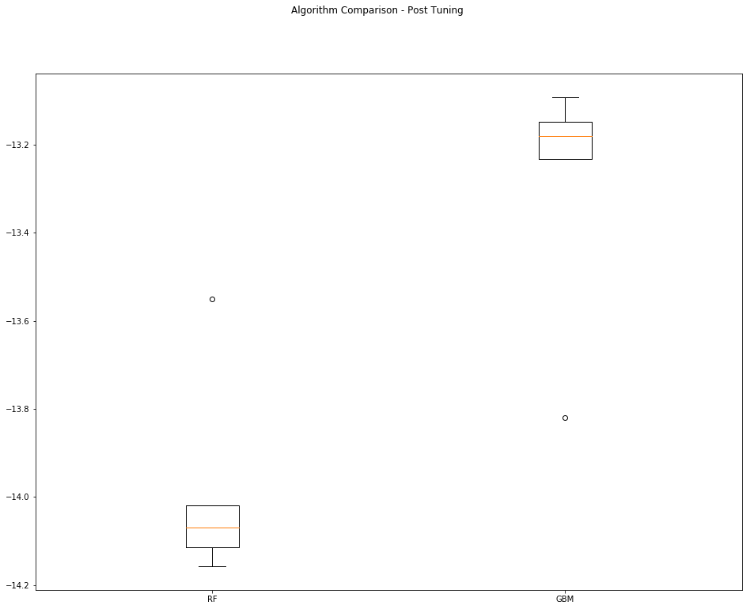

```python
fig = pyplot.figure()
fig.suptitle('Algorithm Comparison - Post Tuning')
ax = fig.add_subplot(111)
pyplot.boxplot(results)
ax.set_xticklabels(names)
pyplot.show()
```

## Section 6 - Finalize Model

Once we have narrow down to a model that we believe can make accurate predictions on unseen data, we are ready to finalize it. Finalizing a model may involve sub-tasks such as:

- Using an optimal model tuned to make predictions on unseen data.
- Creating a standalone model using the tuned parameters
- Saving an optimal model to file for later use.

```python
email_notify("Model Validation and Final Model Creation has begun! "+datetime.now().strftime('%a %B %d, %Y %I:%M:%S %p'))
```

### 6.a) Predictions on validation dataset

```python
model = GradientBoostingRegressor(n_estimators=100, random_state=seedNum)
model.fit(x_train, y_train)
predictions = model.predict(x_test)
print(mean_squared_error(y_test, predictions))
```

```
8.587245063571602
```

### 6.b) Create standalone model on entire training dataset

```python
startTimeModule = datetime.now()
finalModel = GradientBoostingRegressor(n_estimators=100)
finalModel.fit(x_original, y_original)
print ('Model training time:',(datetime.now() - startTimeModule))
```

```
Model training time: 0:00:00.056462
```

### 6.c) Save model for later use

```python
# modelName = 'finalModel_BinaryClass.sav'
# dump(finalModel, modelName)
```

```python
email_notify("Model Validation and Final Model Creation completed! "+datetime.now().strftime('%a %B %d, %Y %I:%M:%S %p'))
print ('Total time for the script:',(datetime.now() - startTimeScript))
```

```
Total time for the script: 0:01:06.973823
```